# Лабораторная работа №5.

## Просмотр содержимого файла

cat - команда для просмотра содержимого файла.

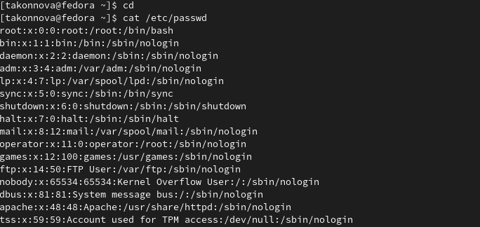

Просмотр содержимого файла passwd

## Копирование файла

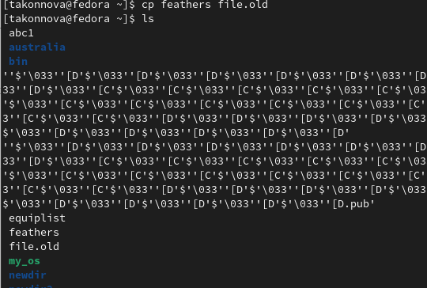

Копирование файла feathers в file.old

## Перемещение файла

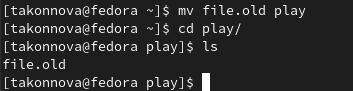

Перемещение файла file.old в каталог play

## Копирование каталога

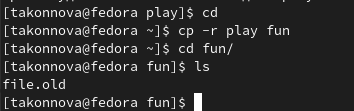

Копирование каталога play в каталог fun

## Перемещение и изменение названия каталога

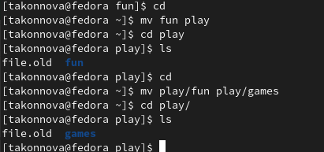

Перемещение каталога fun с изменением название на games

## Работа с правами файла

chmod u-r - команда для лишения владельца файла права на чтение.

chmod u+r - команда для присвоения владельцу файла права на чтение.

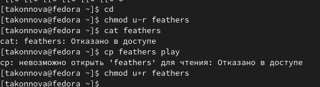

Лишение права на чтение. Попытки чтения и копирования файла. Возвращение права на чтение

## Работа с правами каталога

chmod u-x - команда для лишения владельца каталога права на выполнение.

chmod u+x - команда для присвоения владельцу каталога права на выполнение.

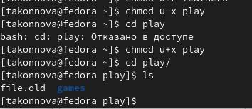

Лишение права на выполнение. Попытка перехода в каталог. Возвращение права на выполнение

# Прочитаем с помощью команды man следующие команды: mount, fsck, mkfs, kill. Кратко охарактеризуем эти команды.

## mount

Для просмотра используемых в операционной системе файловых систем используется команда mount.

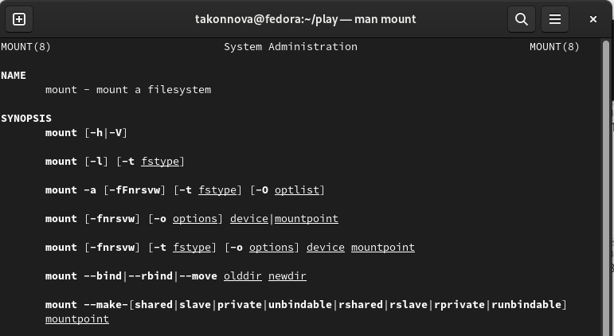

man mount